# Version Control with RStudio and GitHub

Author

Joshua P. French

Published

December 13, 2024

Data scientists should have an intentional process for tracking changes in their code over time.

- This process is known **version control**.

In ancient times, like the early 2000s, we simply renamed our files manually:

- `mycode.R`
- `mycode_v2.R`
- `mycode_final.R`
- `mycode_reallyfinalv2.R`

In modern times, version control is automatic in my contexts.

- Microsoft Word stores versions of a file each time it is saved. We can restore old version if we make a mistake.
- Dropbox automatically saves versions of files each time they are changed. Users can restore old versions of files within a certain time period (30 days to 1 year depending on a user’s subscription level).

The industry standard for version control of computer code and software is git. We will learn how to use git from within R Studio while using GitHub to host our code and version control data.

## What is git?

[figure not shown]

Software developers need a fast, reliable way of tracking changes to their source code when working as individuals or as part of a team.

The best-in-class approach to software version control is git, which was created by Linus Torvalds in 2005 to improve on the version control applications available at the time.

From https://git-scm.com/:

> Git is a free and open source distributed version control system designed to handle everything from small to very large projects with speed and efficiency.

By default, git tracks files changed in a directory or repository locally, i.e., on our actual computer, which can create some potential challenges:

- git does not backup our code or changes, which would be problematic if our computer becomes compromised..
- A centralized repository must be available when multiple contributors are working on the same project. There needs to be a way of easily managing each person’s contributions and keeping track of the development and stable branches of the code.

GitHub is the most popular solution for these two issues.

## What is GitHub?

[figure not shown]

[figure not shown]

GitHub (https://www.github.com) is an online platform for hosting git repositories.

GitHub makes it easy to:

- Control who is able to access and change a repository.
- Track bugs in our code.
- Keep record of feature requests.
- Delegate responsibilities.
- Maintain a wiki.
- etc.

GitHub is a great place to:

- Backup and maintain version control of our software.
- Make our software public and allow others to contribute and interact with our work.
- Demonstrate our coding skills and abilities by creating publicly available project repositories.
- Host a professional website for potential employers or clients.

## Linking RStudio and GitHub

We can use RStudio to manage a local git repository and push the changes to GitHub.com.

We outline the setup process below.

We assume that both R (https://cran.r-project.org/) and RStudio (https://posit.co/downloads) are installed.

### Create a GitHub account

First, we create a GitHub account.

- Navigate to https://github.com
- Click Sign Up.

[figure not shown]

- Choose an email address to associate with your GitHub account.
  - Educational users with a `.edu` email addresses can upgrade for free to a GitHub Pro account.
- Choose a strong password.
- Select a username.
  - Think long term about this username. It may be an account that follows you for much of your professional life!
  - Good choices are related to your name.
    - E.g., if my name is John Q Smith, some good options might be `jsmith`, `jqsmith`, `john-smith`, `john-q-smith`, etc.
  - Bad choices are not professional or unique.
    - E.g., `jsmith198451`, `i-love-cereal`, `PartyKing`.
- Continue the registration process.

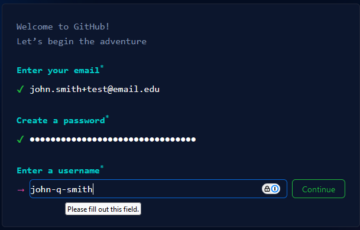

### Install git

Next, we install a version of git to our computer.

Download and install the appropriate version of git from https://git-scm.com/downloads.

[figure not shown]

In general, it is best to install git using all the default settings.

### Verifying communication between git and RStudio

We need to make sure that RStudio is aware of the location of the git program on our computer.

- Navigate to Global Options (under Tools for Windows machines and currently under Edit → Preferences for a Mac).
- Click Git/SVN.

[figure not shown]

Ensure that RStudio has automatically discovered the file path of the git executable.

- If this is not the case, then you will manually have to figure this out.
- You may need to do some web sleuthing to figure out how to do this.

[figure not shown]

To verify that RStudio has the correct path to git:

- Click `Alt + Shift + R` on a Windows computer or `Option + Shift + R` on a Mac to open a new terminal window.
- Type `git --version` in the Terminal window and press enter.
- If RStudio is looking in the correct location for git, then the current install version of git will be printed in the Terminal window.

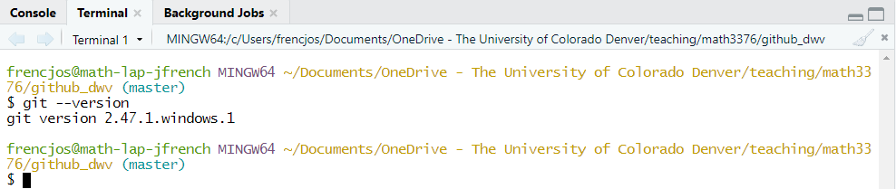

### Authorizing RStudio to access GitHub

Next, we make sure that RStudio can talk with GitHub.

We must specify our username and email address using `git config` via the terminal.

```
git config --global user.name 'myusername'
git config --global user.email 'myemail@email.edu'
```

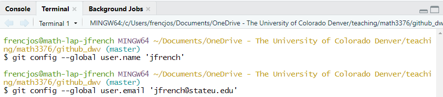

To link RStudio with GitHub, we need to set our GitHub credentials in RStudio.

Install the **gitcreds** package.

- Run `install.packages("gitcreds")` in the R Console.
- Run `library(gitcreds)` in the R Console to attach the **gitcreds** package.

We need to create a Personal Access Token to link RStudio with GitHub.

- Click on your Profile photo.
- Click Settings.

[figure not shown]

- Click Developer settings.

[figure not shown]

- Under Personal Access Tokens, click Tokens (classic).

[figure not shown]

- Write a Note (perhaps which computer the access is being granted to).
- Select when the token will expire (shorter is more secure).
- Select the access we want to grant, if being cautious. **Make sure to select repo access!**
- Click Generate token at the bottom of the page.

[figure not shown]

- Copy the token.

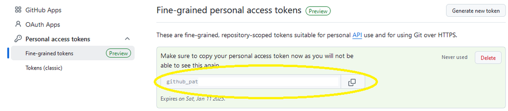

- Run `gitcreds_set()` in the R Console.
- Paste the token you copied into the Console and hit Enter.

RStudio/git should be linked with GitHub!

## RStudio version control when cloning an existing GitHub repository

There are different ways to manage the version control workflow from within R.

We present the most basic workflow, which is to enable version control for a new project cloned from an existing GitHub repository.

### Starting from a “blank” GitHub repository

Create a new repository on GitHub by clicking New on on your GitHub homepage.

- We will create a new repository named “mytest”.

[figure not shown]

- Name your new repository, make it public, click Create Repository.

[figure not shown]

- Copy the url at the top of the repository.

[figure not shown]

### Starting from an established GitHub repository

Navigate to an existing GitHub repository and copy the url at the top of the repository, just like the last step of the previous section.

### Start a version controlled New Project

Next, create a New Project using version control.

- Click File → New Project.
- Click Version Control.

[figure not shown]

- Click Git.

[figure not shown]

- Paste the url, click Create Project.

[figure not shown]

If everything is connected correctly, the newly cloned project should include a Git tab in the Environment pane.

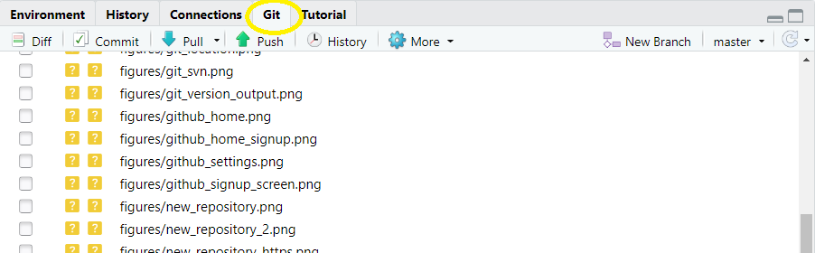

### Basic workflow

The basic workflow when using RStudio to do version control is:

- Add/edit files in the current project.
- Add the appropriate files to the staging area.
- Commit the changes to the local git repository and provide a short description of the changes made.
- Push the changes from the local repository to a remote repository (GitHub).

We provide a simple example.

### Change some code

- Open a new R Script (`Ctrl + Shift + N` on a Windows computer or `Cmd + Shift + N` on a Mac).
- Add a single command to the first line of the file: `print("Hello, world!")`.
- Save the file as `test.R`.

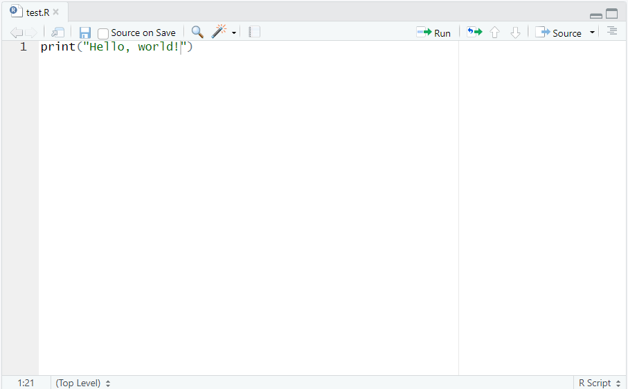

### Stage the changes

In the Git tab of the Environment pane:

- Check the box next to “test.R”.
- Click the Commit button.

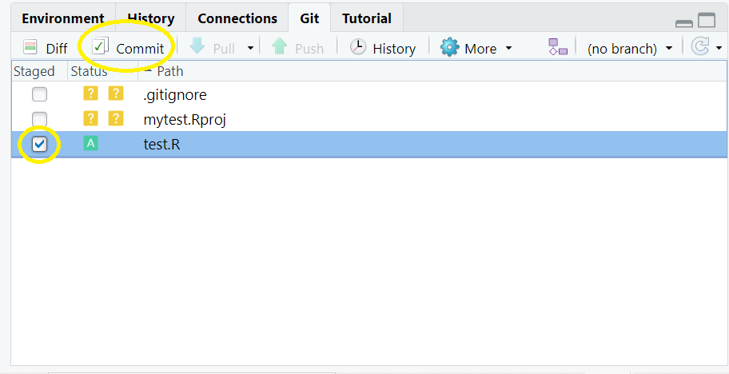

### Commit the changes to the local repository

- Review changes.
- Add a Commit message.
  - This is a brief description of the changes made in the commit.
- Click Commit.

[figure not shown]

### Push the changes to the remote repository

After you close the Commit window, click Push in the Git tab of the Environment pane to push the changes from the local repository to GitHub.

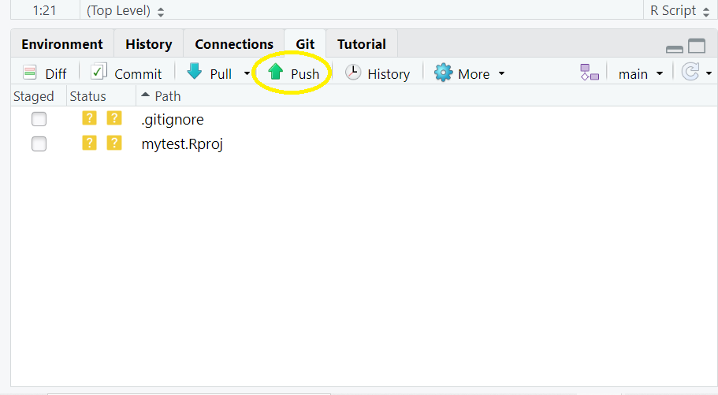

The changes should be pushed to your GitHub repository, which you can see if you go to that repository on your GitHub page.

- We can see that `test.R` has been added to our “mytest” repository on GitHub.

[figure not shown]

## Adding RStudio version control to a local RStudio project

Suppose we want to use version control for a local RStudio project that isn’t already linked to a git repository.

A local RStudio project can be created in two ways.

### Creating a New Project with a New Directory

We first discuss creating a new RStudio project with a new directory.

- Create a New Project by first clicking File → New Project.

[figure not shown]

- Select New Directory.

[figure not shown]

- Name the new directory (“test2” in our case), uncheck the “Create a git repository” box (we will do this manually), and click Create Project.

[figure not shown]